# Developmental trajectories of racial attitudes in young children

Authors

Helen Peng

Smrithi Krishnaswamy

Published

December 14, 2025

## Introduction

Racial attitudes begin to emerge in early childhood and play a central role in shaping children’s social perceptions, preferences, and interactions. Decades of developmental research demonstrate that sensitivity to race and race-based evaluations appear very early and become increasingly structured through childhood. Importantly, these early attitudes are socially constructed through children’s everyday experiences and the social messages they encounter in their families, communities, and schools (Waxman, 2021). By preschool age, children not only notice racial differences but also use race as a meaningful measure to guide their evaluations of others. Thus, their emerging racial categories become infused with the evaluative result, thereby shaping the child’s expectation and beliefs about peers they have never met. These early biases reflect children’s exposure to observed social norms in their environments (Waxman, 2021). As a result, early childhood represents a critical period for understanding how racial attitudes form, allowing us to identify potential entry points for intervention.

A substantial body of prior research suggests that racial attitudes change systematically across development, but these trajectories are neither linear nor uniform. Evidence indicates that ethnic and racial prejudice tends to increase across early childhood, often peaking in middle childhood (approximately ages 5–7), followed by modest declines later in childhood (Raabe & Beelmann, 2011). However, these patterns vary depending on the social status of the groups involved, children’s own group membership, and the broader social context. Additionally, age alone does not fully explain developmental change in racial attitudes. Social experiences, particularly opportunities for intergroup contact, are consistently associated with lower levels of prejudice, though their role in driving change over time remains less clear (Raabe & Beelmann, 2011). This variability highlights the importance of examining individual differences in children’s racial attitudes and identifying contextual factors that may predict stability or change.

Progress in understanding developmental trajectories has been complicated by measurement challenges within the field. A recent systematic review of over 1,000 measures used to assess children’s ethnic and racial attitudes highlights substantial heterogeneity in task design and construct coverage (Fukuda et al., 2025). Measures vary widely in whether they assess evaluative beliefs, social preferences, trait attributions, or behavioral intentions, and these differences are not always explicitly acknowledged. Importantly, tasks that are often grouped together under the umbrella of racial attitudes may measure related but distinct constructs. For example, trait attribution measures assess children’s beliefs about who possesses positive or negative characteristics, whereas social interaction or friendship measures reflect affiliative preferences and social motivations. Evidence suggests that these dimensions are correlated but not interchangeable, and that conclusions about bias can depend heavily on how outcomes are operationalized (Fukuda et al., 2025). Careful attention to measurement choice is therefore essential, particularly when studying developmental change or evaluating intervention effects.

The present study examines developmental trajectories of racial attitudes in young children using two complementary task measures: the Preschool Racial Attitude Measure (PRAM), which assesses evaluative beliefs about peers, and a Friendship task, which assesses social preferences. Our intervention involved classroom instructors or researchers reading stories featuring diverse characters out loud to the children. Children completed both tasks at pretest and posttest surrounding participation in the literacy-based program.

We address two primary research questions.

- Research Question 1 (RQ1): *What predicts individual differences in children’s racial attitudes at pretest?*
- Research Question 2 (RQ2): *Are there identifiable predictors of change in children’s racial attitudes following participation in the literacy program?* By integrating individual-level characteristics with classroom-level measures of racial diversity, we aim to clarify how developmental, social, and contextual factors jointly shape early racial attitudes.

## Methods and Results

### **Analytic Approach Overview**

Our goal was to characterize both baseline individual differences and developmental change in children’s racial attitudes across two task measures. To this end, we adopted a multi-stage analytical strategy. First, we conducted exploratory data analysis to visualize children’s racial choices, trying to examine descriptive patterns across tasks and participant groups. These analyses were use to assess the comparability of the two task measures and to inform subsequent model specification, rather than to test confirmatory hypotheses.

Next, to address RQ1, we examine predictors of individual predictors of individual differences in children’s racial attitudes at pretest using regression-based approaches. Given that children’s choices could reflect distinct preference profiles rather than a single continuous dimension, we modeled outcomes using both logistic and multinomial regression frameworks. This allowed us to distinguish broad tendencies toward pro-White bias from more specific patterns of racial preference. All models included relevant child-level and classroom-level covariates and were estimated separately for the PRAM and Friendship tasks to account for their conceptual differences.

Finally, to addressRQ2, we examined change in racial attitudes from pretest to posttest using logistic regression models with phase and contextual predictors. Details of these analyses are presented following the pretest results.

### **Dataset and Variables Overview**

The sample consisted of 93 children drawn from multiple classrooms, participating in the literacy-based program. Children varied in gender and racial/ethnic background were reported by parents or guardians before pretest.

With respect to gender, the sample included 48 boys, 35 girls, 2 non-binary children, and 8 children with missing gender information. Given the small number of non-binary participants, gender was treated as a binary variable (male vs. female) in regression analyses, with non-binary participants and those missing gender information excluded from models involving this predictor.

Participants also varied in racial and ethnic background. Children identified as White (n = 46), Black (n = 19), Latine (n = 9), East Asian (n = 7), South Asian (n = 3), and Middle Eastern (n = 1); 8 children had missing race/ethnicity information. For analytic purposes, racial/ethnic categories were recoded into a binary variable distinguishing White children (n = 46) from children from minority racial and ethnic groups (n = 39), with participants missing race/ethnicity information excluded from models involving this predictor.

Furthermore, children were nested within classrooms that varied in racial composition. Classroom diversity was quantified using two complementary measures: the Simpson Diversity Index, which captures the balance and evenness of racial groups within a classroom, and a diversity ratio, defined as the proportion of minoritized students in each classroom.

### **Exploratory Data Analysis**

We began by visualizing children’s racial choices across the PRAM and Friendship tasks. Barplots comparing the mean proportion of Asian, Black, and White selections for minoritized and White children (collapsed across timepoints) revealed broadly similar distributions across the two groups.

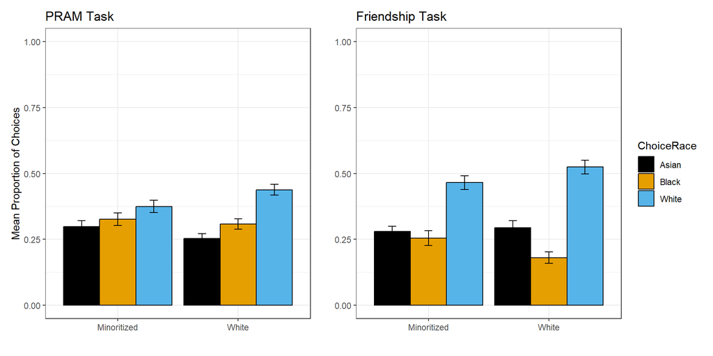

Figure 1: Children from minoritized and White backgrounds showed similar patterns of Asian, Black, and White selections across the PRAM and Friendship tasks, with no clear group-level differences in choice distributions.

To confirm this, we ran a repeated-measures ANOVA with Task (PRAM vs. Friendship) and Choice Race (Asian, Black, White) as within-subject factors and child racial group as a between-subject factor. As suggested by the plots, there was no main effect of racial group and no interactions involving racial group, indicating that minoritized and White children showed comparable choice patterns.

However, children did show a significant main effect of Choice Race, selecting some groups more often than others, and a significant Task × Choice Race interaction, reflecting that the strength of these preferences differed between PRAM and Friendship. This aligns with the idea that who children want to be friends with (Friendship task) is related to but not identical to who they think possesses positive attributes (PRAM task).

To quantify the relationship between the tasks, we correlated children’s pretest scores, as pre-intervention data provide the clearest estimate of the inherent correspondence between the measures. The correlation was r = 0.45, indicating moderate overlap: children who favored White peers in one task tended to do so in the other, but the measures still capture related yet distinct constructs.

Together, these analyses suggest that the PRAM and Friendship tasks tap overlapping but non-identical dimensions of children’s racial attitudes, with no major differences between minoritized and White children at the descriptive level.

### **Research Question 1**

For the first research question, we converted the continuous outcome variable Proportion of White Choices into categorical outcomes. We ran both binary logistic regression models and multinomial regression models.

In the binary logistic models, we recoded the outcome such that if a participant selected White more than 50% of the time, they were categorized as showing a pro-White bias (1); otherwise, they were categorized as showing no bias (0). Multiple logistic regression models were then conducted to test a range of predictors and interactions.

In both tasks, some trials included three girl options and three boy options. Because children often select same-gender peers, we created a new variable, Proportion Same-Gender Choices, to control for this matching effect. Specifically, if a participant was a boy, the variable reflected the proportion of boy choices; if a girl, the proportion of girl choices. This control variable was included in all relevant models to account for gender-based selection tendencies.

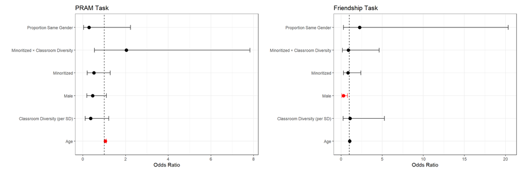

Figure 2: Logistic regression revealed that age significantly predicted bias in the PRAM Task (older children more pro-White), while gender significantly predicted bias in the Friendship Task (females more pro-White)

To further examine predictors of individual differences in children’s racial attitudes at pretest, we fit multinomial logistic regression models separately for the PRAM and Friendship tasks. In both models, White bias and gender female served as the reference category, allowing us to compare predictors of Black bias, Asian bias, and no clear preference (tie) relative to a pro-White pattern. Predictor variables included child gender and racial/ethnic identity (White vs. minoritized).

Multinomial Regression Results (PRAM Bias Groups)

|  | estimate | std_error | z | p_value | OR |
| --- | --- | --- | --- | --- | --- |
| (Intercept):1 | -0.965 | 0.383 | -2.520 | 0.012 | 0.381 |
| (Intercept):2 | -1.312 | 0.436 | -3.011 | 0.003 | 0.269 |
| (Intercept):3 | -0.905 | 0.373 | -2.426 | 0.015 | 0.405 |
| GenderMale:1 | 0.852 | 0.447 | 1.907 | 0.056 | 2.345 |
| GenderMale:2 | 0.432 | 0.506 | 0.854 | 0.393 | 1.540 |
| GenderMale:3 | 1.035 | 0.432 | 2.394 | 0.017 | 2.815 |
| RacialEthnicRecodedMinoritized:1 | 0.898 | 0.456 | 1.971 | 0.049 | 2.455 |
| RacialEthnicRecodedMinoritized:2 | 1.119 | 0.516 | 2.169 | 0.030 | 3.063 |
| RacialEthnicRecodedMinoritized:3 | 0.906 | 0.439 | 2.062 | 0.039 | 2.475 |

Note:  
Outcome codes: 1 = Pro-Black, 2 = Pro-Asian, 3 = Tie (White = reference).

Results from the multinomial regression for the PRAM task revealed consistent effects of children’s racial/ethnic identity across bias categories. Compared to White children, children from minoritized racial and ethnic groups were significantly more likely to show Black bias relative to White bias (OR = 2.46, p = .049), Asian bias relative to White bias (OR = 3.06, p = .030), and no clear preference (tie) relative to White bias (OR = 2.48, p = .039). These findings suggest that, in the PRAM task, children’s own racial/ethnic identity was associated with a reduced likelihood of exhibiting a pro-White evaluative pattern and an increased likelihood of endorsing alternative or non-exclusive preferences.

Multinomial Regression Results (Friendship Bias Groups)

|  | estimate | std_error | z | p_value | OR |
| --- | --- | --- | --- | --- | --- |
| (Intercept):1 | -2.658 | 0.771 | -3.449 | 0.001 | 0.070 |
| (Intercept):2 | -1.695 | 0.564 | -3.004 | 0.003 | 0.184 |
| (Intercept):3 | -2.439 | 0.749 | -3.257 | 0.001 | 0.087 |
| GenderMale:1 | 1.377 | 0.760 | 1.812 | 0.070 | 3.963 |
| GenderMale:2 | 1.314 | 0.616 | 2.132 | 0.033 | 3.721 |
| GenderMale:3 | 1.073 | 0.781 | 1.373 | 0.170 | 2.924 |
| RacialEthnicRecodedMinoritized:1 | 1.070 | 0.723 | 1.479 | 0.139 | 2.914 |
| RacialEthnicRecodedMinoritized:2 | 0.284 | 0.593 | 0.480 | 0.631 | 1.329 |
| RacialEthnicRecodedMinoritized:3 | 0.721 | 0.755 | 0.954 | 0.340 | 2.056 |

Note:  
Outcome codes: 1 = Pro-Black, 2 = Pro-Asian, 3 = Tie (White = reference).

In contrast to the PRAM task, the multinomial regression for the Friendship task showed a different pattern of predictors. Gender emerged as the primary predictor of bias category membership. Boys were significantly more likely than girls to show Asian bias relative to White bias (OR = 3.72, p = .033) and marginally more likely to show Black bias relative to White bias (OR = 3.96, p = .07). Gender did not significantly predict tie outcomes in the Friendship task (p = .17).

Children’s racial/ethnic identity did not significantly predict bias category membership in the Friendship task. Minoritized and White children did not differ in their likelihood of showing Black bias, Asian bias, or tie outcomes relative to White bias (all p values > 0.1).

Across analytic approaches, results indicate that predictors of children’s racial attitudes at pretest depended both on the task and method of analysis. Binary logistic regression models, which captured broad tendencies toward pro-White bias, revealed that age was a significant predictor in the PRAM task, with older children more likely to exhibit pro-White evaluative patterns, whereas gender was a significant predictor in the Friendship task, with boys less likely to show pro-White social preferences. These findings suggest that developmental and gender-related factors influence children’s racial attitudes differently depending on whether the task measures evaluative judgments or social affiliation.

Multinomial regression models provided a more nuanced account by distinguishing between pro-White, pro-Black, pro-Asian, and no clear preference profiles. In the PRAM task, children’s racial/ethnic identity emerged as a consistent predictor across bias categories: children from minoritized backgrounds were significantly more likely than White children to show non-White or mixed evaluative patterns relative to pro-White bias. In contrast, racial/ethnic identity did not predict bias category membership in the Friendship task. Instead, gender remained the primary source of variation, with boys more likely to exhibit non-White friendship preferences. Together, these results demonstrate that binary models capture broad directional tendencies, whereas multinomial models reveal race-specific and task-dependent patterns that can be obscured. This convergence across modeling approaches underscores the importance of both measurement choice and analytic specification in understanding individual differences in children’s early racial attitudes.

### **Research Question 2**

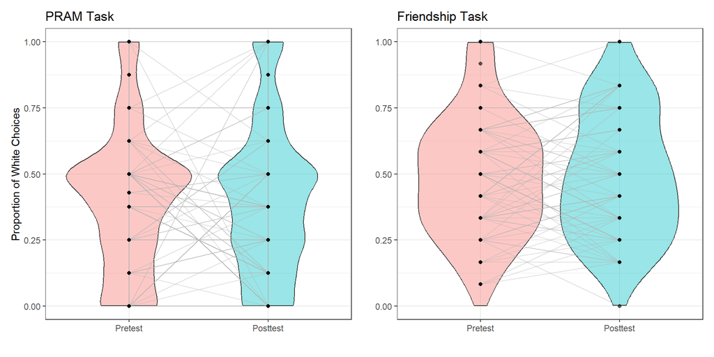

Figure 3: Violin plot shows no overall change in the distribution of white choices from pretest to posttest in either task.

To get an initial sense of change, we first inspected the raw distributions of children’s proportion of White selections at pretest and posttest. As shown in the visualization, the distributions are highly similar across timepoints, indicating no obvious shift in the frequency with which children selected White targets.

For our formal analyses, we considered multilevel approaches to account for potential clustering, but the data structure provided only one pretest and one posttest score per child and too few observations per group to estimate random effects reliably. We therefore used logistic regression to model change across time, using the variable Phase as a main effect, along with its interactions with other covariates. This would allow us to still account for the differences between children at baseline.

Consistent with the visualization, the logistic models showed no overall change in pro-White bias from pretest to posttest in either task. However, diversity index emerged as a significant predictor at posttest for both measures. Thus, although the program itself did not produce a detectable shift in bias, the diversity of children’s environments was meaningfully related to their post-intervention attitudes.

We then examined whether this pattern depended on how classroom composition was quantified. The Simpson Diversity Index, used in the main analyses, reflects the balance and evenness across racial groups but cannot distinguish a classroom that is 100 percent White from one that is 100 percent Black. In contrast, the diversity ratio (minoritized / total) captures the presence of minoritized children but it does not represent multi-group diversity as effectively. Each measure therefore captures different aspects of classroom composition.

However, after running the same analysis we found that the diversity effect vanishes when using diversity ratio over diversity index. This suggests that it’s not just the number of minoritized children in a classroom that matters, but the overall balance of different racial groups.

In addition to classroom composition, we examined child-level predictors. Age predicted pro-White bias in the PRAM task at pretest but not at posttest, suggesting that the intervention may help level out age-related differences. Gender predicted pro-White bias in the Friendship task at both pre- and posttest, with boys showing consistently lower pro-White selections.

See appendix for the estimates and p-values of these models.

## Discussion

The present study examined individual differences and developmental change in young children’s racial attitudes using two complementary task measures. Across analyses, we found that children’s racial attitudes at pretest were meaningfully structured, but short-term change following participation in a literacy-based program was limited. Importantly, predictors of racial attitudes differed by task and analytic approach, highlighting the importance of measurement choice when characterizing early racial biases.

Consistent with prior work, children’s racial attitudes at pretest showed systematic variation as a function of both individual characteristics and task demands. In binary logistic models, older children were more likely to show pro-White evaluative patterns in the PRAM task, whereas gender emerged as a significant predictor of pro-White bias in the Friendship task. These findings align with evidence that evaluative beliefs and social preferences follow partially distinct developmental pathways (Waxman, 2021; Fukuda et al., 2025). Multinomial models further revealed that children’s own racial/ethnic identity was a robust predictor of evaluative bias in the PRAM task but not of social preferences in the Friendship task. Specifically, children from minoritized backgrounds were less likely to show pro-White evaluative patterns. This pattern is consistent with developmental research demonstrating that children’s group membership shapes how they interpret and evaluate social categories, even in early childhood (Raabe & Beelmann, 2011; Waxman, 2021).

Despite clear individual differences at baseline, we observed no overall shift in racial attitudes from pretest to posttest in either task. This absence of short-term change is informative rather than surprising. Developmental theories suggest that racial attitudes are shaped by cumulative social experience and structural context, and may therefore be resistant to change over brief intervention periods (Raabe & Beelmann, 2011). Moreover, early biases may reflect broader societal messages that extend beyond the scope of a single educational program (Waxman, 2021). Notably, classroom diversity emerged as a significant predictor of posttest attitudes when diversity was measured using a balance-based metric (Simpson Diversity Index), but not when using a simple proportion-based one. This finding suggests that the structure of children’s social environments, rather than the mere presence of minoritized peers, may be especially relevant for shaping racial attitudes, supporting prior work emphasizing the role of sustained, meaningful intergroup exposure.

Taken together, these findings suggest that early racial attitudes are already patterned but relatively stable over short time spans. The task-specific predictors observed here highlight that racial attitudes are not a unitary construct, evaluative beliefs and social preferences may respond to different developmental and contextual influences. This distinction has important implications for how racial attitudes are measured and interpreted in early childhood research (Fukuda et al., 2025). More broadly, the results reinforce the view that early childhood represents a sensitive period for the formation, but not necessarily rapid modification, of racial attitudes. Structural features of children’s everyday environments, such as classroom diversity, may play a more influential role than brief programmatic exposure in shaping developmental trajectories.

### **Limitations**

Several limitations should be acknowledged. First, the sample size was modest, which limited statistical power, particularly for detecting small effects and estimating complex multilevel models. Second, the study included only two timepoints, restricting our ability to model nonlinear developmental change. Third, while the use of multiple task measures is a strength, both tasks rely on forced-choice paradigms that may not fully capture the complexity of children’s racial reasoning.

### **Future Directions**

Several avenues for future work emerge from the present findings. First, future analyses will incorporate data from a third task, the Spatial Arrangement Method (SpAM), which was piloted but not included in the present study. Unlike the PRAM and Friendship tasks, which rely on forced-choice responses, SpAM provides a continuous, spatial measure of children’s perceived social relationships. Including this task will allow for a broader assessment of children’s racial attitudes and may capture dimensions of bias not detectable through categorical choice paradigms.

Second, although the current analyses focused on a subset of demographic predictors, the preregistration specifies additional exploratory variables available in the participant information data. Future work will revisit these preregistered exploratory analyses to assess whether other child or family characteristics help explain individual differences or change in racial attitudes, particularly as sample sizes increase.

## Appendix

Repeated Measures ANOVA Results

|  | num Df | den Df | MSE | F | ges | Pr(>F) |
| --- | --- | --- | --- | --- | --- | --- |
| RacialEthnicRecoded | 1.000 | 77.000 | 0.000 | -0.002 | 0.000 | 1.000 |
| Task | 1.000 | 77.000 | 0.000 | 0.000 | 0.000 | 1.000 |
| RacialEthnicRecoded:Task | 1.000 | 77.000 | 0.000 | -0.001 | 0.000 | 1.000 |
| ChoiceRace | 1.932 | 148.767 | 0.085 | 18.972 | 0.149 | 0.000 |
| RacialEthnicRecoded:ChoiceRace | 1.932 | 148.767 | 0.085 | 1.203 | 0.011 | 0.302 |
| Task:ChoiceRace | 1.949 | 150.081 | 0.034 | 10.539 | 0.038 | 0.000 |
| RacialEthnicRecoded:Task:ChoiceRace | 1.949 | 150.081 | 0.034 | 0.655 | 0.002 | 0.517 |

Baseline PRAM Task Logistic Regression Results

| term | estimate | std.error | statistic | p.value | conf.low | conf.high | OR | OR_low | OR_high |
| --- | --- | --- | --- | --- | --- | --- | --- | --- | --- |
| GenderMale | -0.777 | 0.450 | -1.726 | 0.084 | -1.680 | 0.098 | 0.460 | 0.186 | 1.103 |
| PretestAge | 0.054 | 0.022 | 2.473 | 0.013 | 0.013 | 0.098 | 1.055 | 1.013 | 1.103 |
| RacialEthnicRecodedMinoritized | -0.653 | 0.470 | -1.390 | 0.165 | -1.613 | 0.248 | 0.520 | 0.199 | 1.282 |
| scale(diversityIndex) | -1.003 | 0.616 | -1.627 | 0.104 | -2.247 | 0.196 | 0.367 | 0.106 | 1.217 |
| prop_same_gender | -1.236 | 1.059 | -1.167 | 0.243 | -3.382 | 0.802 | 0.290 | 0.034 | 2.230 |
| RacialEthnicRecodedMinoritized:scale(diversityIndex) | 0.710 | 0.671 | 1.058 | 0.290 | -0.604 | 2.058 | 2.034 | 0.547 | 7.830 |

Baseline Friendship Task Logistic Regression Results

| term | estimate | std.error | statistic | p.value | conf.low | conf.high | OR | OR_low | OR_high |
| --- | --- | --- | --- | --- | --- | --- | --- | --- | --- |
| GenderMale | -1.268 | 0.525 | -2.415 | 0.016 | -2.333 | -0.258 | 0.281 | 0.097 | 0.772 |
| PretestAge | 0.032 | 0.024 | 1.327 | 0.185 | -0.015 | 0.082 | 1.033 | 0.985 | 1.085 |
| RacialEthnicRecodedMinoritized | -0.189 | 0.539 | -0.351 | 0.725 | -1.252 | 0.879 | 0.828 | 0.286 | 2.409 |
| scale(diversityIndex) | 0.084 | 0.780 | 0.108 | 0.914 | -1.446 | 1.662 | 1.088 | 0.236 | 5.271 |
| prop_same_gender | 0.812 | 1.070 | 0.758 | 0.448 | -1.260 | 3.013 | 2.252 | 0.284 | 20.346 |
| RacialEthnicRecodedMinoritized:scale(diversityIndex) | -0.126 | 0.846 | -0.149 | 0.881 | -1.832 | 1.533 | 0.881 | 0.160 | 4.633 |

PRAM Change with Diversity Index Logistic Regression Results

| term | estimate | std.error | statistic | p.value | conf.low | conf.high | OR | OR_low | OR_high |
| --- | --- | --- | --- | --- | --- | --- | --- | --- | --- |
| PhasePretest | -1.188 | 1.824 | -0.651 | 0.515 | -4.821 | 2.392 | 0.305 | 0.008 | 10.932 |
| PhasePosttest:GenderMale | 0.121 | 0.423 | 0.287 | 0.774 | -0.701 | 0.968 | 1.129 | 0.496 | 2.633 |
| PhasePretest:GenderMale | -0.632 | 0.427 | -1.479 | 0.139 | -1.483 | 0.202 | 0.532 | 0.227 | 1.224 |
| PhasePosttest:RacialEthnicRecodedWhite | 0.654 | 0.454 | 1.443 | 0.149 | -0.213 | 1.582 | 1.924 | 0.808 | 4.866 |
| PhasePretest:RacialEthnicRecodedWhite | 0.691 | 0.469 | 1.472 | 0.141 | -0.206 | 1.654 | 1.995 | 0.814 | 5.229 |
| PhasePosttest:PretestAge | 0.033 | 0.020 | 1.660 | 0.097 | -0.005 | 0.073 | 1.033 | 0.995 | 1.076 |
| PhasePretest:PretestAge | 0.056 | 0.021 | 2.700 | 0.007 | 0.017 | 0.100 | 1.058 | 1.017 | 1.105 |
| PhasePosttest:scale(diversityIndex) | -0.627 | 0.194 | -3.225 | 0.001 | -1.034 | -0.256 | 0.534 | 0.355 | 0.774 |
| PhasePretest:scale(diversityIndex) | -0.376 | 0.228 | -1.652 | 0.098 | -0.808 | 0.122 | 0.687 | 0.446 | 1.130 |

Friendship Change with Diversity Index Logistic Regression Results

| term | estimate | std.error | statistic | p.value | conf.low | conf.high | OR | OR_low | OR_high |
| --- | --- | --- | --- | --- | --- | --- | --- | --- | --- |
| PhasePretest | -0.475 | 1.890 | -0.251 | 0.801 | -4.201 | 3.257 | 0.622 | 0.015 | 25.961 |
| PhasePosttest:GenderMale | -1.271 | 0.527 | -2.410 | 0.016 | -2.346 | -0.262 | 0.281 | 0.096 | 0.769 |
| PhasePretest:GenderMale | -1.381 | 0.506 | -2.729 | 0.006 | -2.409 | -0.413 | 0.251 | 0.090 | 0.662 |
| PhasePosttest:RacialEthnicRecodedWhite | -0.068 | 0.535 | -0.127 | 0.899 | -1.126 | 0.988 | 0.935 | 0.324 | 2.685 |
| PhasePretest:RacialEthnicRecodedWhite | 0.236 | 0.524 | 0.451 | 0.652 | -0.796 | 1.275 | 1.266 | 0.451 | 3.578 |
| PhasePosttest:PretestAge | 0.028 | 0.023 | 1.223 | 0.221 | -0.016 | 0.076 | 1.029 | 0.984 | 1.079 |
| PhasePretest:PretestAge | 0.037 | 0.023 | 1.609 | 0.108 | -0.007 | 0.083 | 1.037 | 0.993 | 1.086 |
| PhasePosttest:scale(diversityIndex) | -0.628 | 0.300 | -2.092 | 0.036 | -1.354 | -0.102 | 0.534 | 0.258 | 0.903 |
| PhasePretest:scale(diversityIndex) | -0.028 | 0.275 | -0.103 | 0.918 | -0.543 | 0.602 | 0.972 | 0.581 | 1.826 |

PRAM Change with Diversity Ratio Logistic Regression Results

| term | estimate | std.error | statistic | p.value | conf.low | conf.high | OR | OR_low | OR_high |
| --- | --- | --- | --- | --- | --- | --- | --- | --- | --- |
| PhasePretest | -0.087 | 2.195 | -0.040 | 0.968 | -4.439 | 4.236 | 0.917 | 0.012 | 69.114 |
| PhasePosttest:GenderMale | 0.105 | 0.412 | 0.254 | 0.799 | -0.696 | 0.929 | 1.110 | 0.498 | 2.532 |
| PhasePretest:GenderMale | -0.566 | 0.427 | -1.324 | 0.186 | -1.417 | 0.269 | 0.568 | 0.242 | 1.309 |
| PhasePosttest:RacialEthnicRecodedWhite | 0.642 | 0.443 | 1.451 | 0.147 | -0.208 | 1.540 | 1.901 | 0.812 | 4.667 |
| PhasePretest:RacialEthnicRecodedWhite | 0.588 | 0.471 | 1.250 | 0.211 | -0.313 | 1.549 | 1.801 | 0.731 | 4.708 |
| PhasePosttest:PretestAge | 0.040 | 0.025 | 1.636 | 0.102 | -0.007 | 0.091 | 1.041 | 0.994 | 1.095 |
| PhasePretest:PretestAge | 0.044 | 0.026 | 1.690 | 0.091 | -0.005 | 0.097 | 1.045 | 0.995 | 1.102 |
| PhasePosttest:scale(diversityRatio) | 0.368 | 0.293 | 1.254 | 0.210 | -0.215 | 0.949 | 1.445 | 0.807 | 2.583 |
| PhasePretest:scale(diversityRatio) | -0.184 | 0.383 | -0.482 | 0.630 | -0.987 | 0.533 | 0.832 | 0.373 | 1.704 |

Friendship Change with Diversity Ratio Logistic Regression Results

| term | estimate | std.error | statistic | p.value | conf.low | conf.high | OR | OR_low | OR_high |
| --- | --- | --- | --- | --- | --- | --- | --- | --- | --- |
| PhasePretest | 0.897 | 2.345 | 0.383 | 0.702 | -3.703 | 5.548 | 2.452 | 0.025 | 256.717 |
| PhasePosttest:GenderMale | -1.108 | 0.505 | -2.195 | 0.028 | -2.127 | -0.134 | 0.330 | 0.119 | 0.874 |
| PhasePretest:GenderMale | -1.275 | 0.513 | -2.484 | 0.013 | -2.315 | -0.289 | 0.279 | 0.099 | 0.749 |
| PhasePosttest:RacialEthnicRecodedWhite | -0.122 | 0.534 | -0.229 | 0.819 | -1.179 | 0.931 | 0.885 | 0.307 | 2.536 |
| PhasePretest:RacialEthnicRecodedWhite | 0.053 | 0.541 | 0.097 | 0.922 | -1.019 | 1.119 | 1.054 | 0.361 | 3.061 |
| PhasePosttest:PretestAge | 0.026 | 0.028 | 0.907 | 0.364 | -0.029 | 0.082 | 1.026 | 0.972 | 1.086 |
| PhasePretest:PretestAge | 0.011 | 0.029 | 0.382 | 0.703 | -0.045 | 0.068 | 1.011 | 0.956 | 1.071 |
| PhasePosttest:scale(diversityRatio) | 0.051 | 0.351 | 0.145 | 0.884 | -0.658 | 0.740 | 1.052 | 0.518 | 2.096 |
| PhasePretest:scale(diversityRatio) | -0.557 | 0.408 | -1.364 | 0.173 | -1.423 | 0.199 | 0.573 | 0.241 | 1.220 |

## References

Waxman, S. R. (2021). Racial awareness and bias begin early: Developmental entry points, challenges, and a call to action. **Perspectives on Psychological Science, 16**(5), 893–902. https://doi.org/10.1177/17456916211026968  
Raabe, T., & Beelmann, A. (2011). Development of ethnic, racial, and national prejudice in childhood and adolescence: A multinational meta-analysis of age differences. **Child Development, 82**(6), 1715–1737. https://doi.org/10.1111/j.1467-8624.2011.01668.x  
Fukuda, E., Scott, K. E., Swerbenski, K. L., et al. (2025). A systematic review of modern measures for capturing children’s ethnic and racial attitudes, stereotypes, and discrimination. **Developmental Review, 76**, 101189. https://doi.org/10.1016/j.dr.2025.101189